# III - 0D computations

## 1. Knowledge of 0D computations

The following link may help you to find the answers or the documentation you need : https://cantera.org/documentation/docs-2.4/sphinx/html/cython/zerodim.html https://cantera.org/science/reactors.html  
The first one is about the function that can be used for computing a reactor and the second one explains the equations that are computed.

### ReactorBase class

0D Reactors are often used in combustion to model auto-ignition time and the chemistry associated to it. For reactors and reservoirs, the classe used *ReactorBase* is the following :  
`ReactorBase(ThermoPhase contents, name=None, arguments)`  
Here are the different types of reactors you can have for a 0D computation :

1. **Reservoir**  
   Reactors with a constant state. The temperature, pressure, and chemical composition in a reservoir never change from their initial values.
2. **Reactor**
3. **IdealGasReactor**  
   Constant volume, zero-dimensional reactor for ideal gas mixtures.
4. **ConstPressureReactor**  
   Homogeneous, constant pressure, zero-dimensional reactor. The volume of the reactor changes as a function of time in order to keep the pressure constant.
5. **IdealGasConstPressureReactor**  
   Homogeneous, constant pressure, zero-dimensional reactor for ideal gas mixtures. The volume of the reactor changes as a function of time in order to keep the pressure constant.
6. **FlowReactor**  
   A steady-state plug flow reactor with constant cross sectional area. Time integration follows a fluid element along the length of the reactor. The reactor is assumed to be frictionless and adiabatic.

### FlowDevice class

Reactors can be added inlets and outlets, to be able to loop or chain several reactors, control mass flow rates, volume or pressure. Here are the properties of the common baseclass *FlowDevice* for flow controllers between reactors and reservoirs :  
`FlowDevice(upstream, downstream, name=None, arguments)`  
The FlowDevice controls the fluids passage between an upstream and a downstream object, which should be specified. The arguments depend upon the different types of flow controllers available in Cantera :

1. **MassFlowController**  
   Mass flow controllers maintain a specified mass flow rate independent of upstream and downstream conditions. Unlike a real mass flow controller, a MassFlowController object will maintain the flow even if the downstream pressure is greater than the upstream pressure.
2. **Valve**  
   Valves are flow devices with mass flow rate that is a function of the pressure drop across them. Valve objects are often used between an upstream reactor and a downstream reactor or reservoir to maintain them both at nearly the same pressure. By setting the constant Kv to a sufficiently large value, very small pressure differences will result in flow between the reactors that counteracts the pressure difference.
3. **PressureController**  
   A pressure controller is designed to be used in conjunction, typically, with a MassFlowController. The master flow controller is installed on the inlet of the reactor, and the corresponding PressureController is installed on the outlet of the reactor. The PressureController mass flow rate is equal to the master mass flow rate, plus a small correction dependent on the pressure difference.

### Walls

Reactors can also add heat transfer and heterogeneous reactions at the walls, through a special object "wall". Walls separate two reactors, or a reactor and a reservoir. A wall has a finite area, may conduct or radiate heat between the two reactors on either side, and may move like a piston. They are stateless objects in Cantera, meaning that no differential equation is integrated to determine any wall property. A heterogeneous reaction mechanism may be specified for one or both of the wall surfaces.

### ReactorNet

Now, the evolution of a reactor, or a network of reactors -which are 0-D objects- with time, is performed through an integrator object *ReactorNet* :

There are two possibilities to advance a reactor simulation in time :

## 2. Simple closed vessel

### Import statements

```python
import sys
import numpy as np
import cantera as ct
import matplotlib.pyplot as plt
from matplotlib import *
```

### Set the mechanism properties

```python
gas = ct.Solution('gri30.cti')
gas.TPX = 1000.0, ct.one_atm, 'CH4:0.5,O2:1,N2:3.76'
```

### Create the reactor and the ReactorNet associated to it

```python
# Create Reactor and fill with gas
r = ct.Reactor(gas)

# Prepare the simulation with a ReactorNet object
sim = ct.ReactorNet([r])
time = 4.e-1
```

### Compute the reactor

```python
# Arrays to hold the datas
n_points = 400
times = np.zeros(n_points)
data = np.zeros((n_points, 4))

# Advance the simulation in time
# and print the internal evolution of temperature, volume and internal energy
print(('%10s %10s %10s %14s' % ('t [s]', 'T [K]', 'vol [m3]', 'u [J/kg]')))
for n in range(n_points):
    time += 5.e-3
    sim.advance(time)
    times[n] = time  # time in s
    data[n, 0] = r.T                               # set the temperature in the first column
    data[n, 1:] = r.thermo['O2', 'CO2', 'CH4'].X     # set the molar fractions in the other column
    print(('%10.3e %10.3f %10.3f %14.6e' % (sim.time, r.T,
                                            r.thermo.v, r.thermo.u)))
```

```
     t [s]      T [K]   vol [m3]       u [J/kg]
 4.050e-01   1001.116      2.970   2.870654e+05
 4.100e-01   1001.143      2.970   2.870654e+05
 4.150e-01   1001.172      2.970   2.870654e+05
 4.200e-01   1001.201      2.970   2.870654e+05
 4.250e-01   1001.230      2.970   2.870654e+05
 4.300e-01   1001.260      2.970   2.870654e+05
 4.350e-01   1001.291      2.970   2.870654e+05
 4.400e-01   1001.322      2.970   2.870654e+05
 4.450e-01   1001.354      2.970   2.870654e+05
 4.500e-01   1001.386      2.970   2.870654e+05
 4.550e-01   1001.419      2.970   2.870654e+05
 4.600e-01   1001.453      2.970   2.870654e+05
 4.650e-01   1001.487      2.970   2.870654e+05
 4.700e-01   1001.522      2.970   2.870654e+05
 4.750e-01   1001.558      2.970   2.870654e+05
 4.800e-01   1001.594      2.970   2.870654e+05
 4.850e-01   1001.631      2.970   2.870654e+05
 4.900e-01   1001.669      2.970   2.870654e+05
 4.950e-01   1001.708      2.970   2.870654e+05
 5.000e-01   1001.747      2.970   2.870654e+05
 5.050e-01   1001.787      2.970   2.870654e+05
 5.100e-01   1001.828      2.970   2.870654e+05
 5.150e-01   1001.870      2.970   2.870654e+05
 5.200e-01   1001.912      2.970   2.870654e+05
 5.250e-01   1001.956      2.970   2.870654e+05
 5.300e-01   1002.000      2.970   2.870654e+05
 5.350e-01   1002.046      2.970   2.870654e+05
 5.400e-01   1002.092      2.970   2.870654e+05
 5.450e-01   1002.139      2.970   2.870654e+05
 5.500e-01   1002.187      2.970   2.870654e+05
 5.550e-01   1002.236      2.970   2.870654e+05
 5.600e-01   1002.287      2.970   2.870654e+05
 5.650e-01   1002.338      2.970   2.870654e+05
 5.700e-01   1002.390      2.970   2.870654e+05
 5.750e-01   1002.444      2.970   2.870654e+05
 5.800e-01   1002.498      2.970   2.870654e+05
 5.850e-01   1002.554      2.970   2.870654e+05
 5.900e-01   1002.611      2.970   2.870654e+05
 5.950e-01   1002.669      2.970   2.870654e+05
```

[output cut: 346 more lines]

```
 2.330e+00   2768.160      2.970   2.870654e+05
 2.335e+00   2768.160      2.970   2.870654e+05
 2.340e+00   2768.160      2.970   2.870654e+05
 2.345e+00   2768.160      2.970   2.870654e+05
 2.350e+00   2768.160      2.970   2.870654e+05
 2.355e+00   2768.160      2.970   2.870654e+05
 2.360e+00   2768.160      2.970   2.870654e+05
 2.365e+00   2768.160      2.970   2.870654e+05
 2.370e+00   2768.160      2.970   2.870654e+05
 2.375e+00   2768.160      2.970   2.870654e+05
 2.380e+00   2768.160      2.970   2.870654e+05
 2.385e+00   2768.160      2.970   2.870654e+05
 2.390e+00   2768.160      2.970   2.870654e+05
 2.395e+00   2768.160      2.970   2.870654e+05
 2.400e+00   2768.160      2.970   2.870654e+05
```

### Plot results

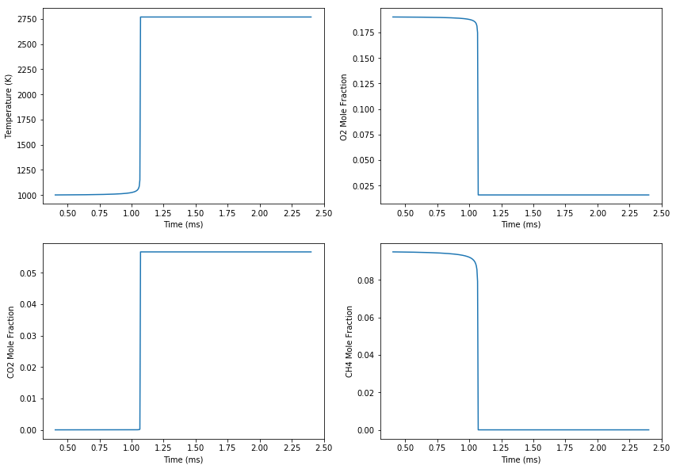

```python
rcParams['figure.figsize'] = (14, 10)

plt.clf()

plt.subplot(2, 2, 1)
plt.plot(times, data[:, 0])
plt.xlabel('Time (ms)')
plt.ylabel('Temperature (K)')

plt.subplot(2, 2, 2)
plt.plot(times, data[:, 1])
plt.xlabel('Time (ms)')
plt.ylabel('O2 Mole Fraction')

plt.subplot(2, 2, 3)
plt.plot(times, data[:, 2])
plt.xlabel('Time (ms)')
plt.ylabel('CO2 Mole Fraction')

plt.subplot(2, 2, 4)
plt.plot(times, data[:, 3])
plt.xlabel('Time (ms)')
plt.ylabel('CH4 Mole Fraction')

plt.show()
```

There are the characteristic evolutions that one can observe when simulating 0D cases. You should be aware that your case must auto-ignite (for some temperature, it is not sufficiently hot to auto-ignite, therefore nothing happens) and that the simulated time should be sufficient to capture the time where it ignites.

Try to move the temperature of the gas state :  
- at 960 K  
- at 1040 K  
What do you observe ?

As you can see, slightly shifting the temperature up or down moves the auto-ignition time. As you never know a priori the order of magnitude of the ignition time, it is good to use the step version until you reach burnt gases.

## 3. A simple constant pressure reactor

Here, we want to create a simple constant pressure reactor. To do so, it is necessary to create a reactor and its environment (which will be a Reservoir). The interface between the two objects created is handled by a wall, of which the expansion rate can be defined by the user.

### Set the mechanism properties

```python
# Mechanisms used for the process
gri3 = ct.Solution('gri30.xml')
air = ct.Solution('air.xml')

# Gas state
gri3.TPX = 1000.0, ct.one_atm, 'CH4:0.5,O2:1,N2:3.76'
```

### Set the reservoir

Try to set :  
- an IdealGasReactor object with the gri3 object created above  
- a Reservoir representing the environment with the air object created above

```python
# Reactor and environment
r = ct.IdealGasReactor(gri3)
env = ct.Reservoir(air)

# Wall
w = ct.Wall(r, env)
w.expansion_rate_coeff = 1.0e6  # set expansion parameter. dV/dt = KA(P_1 - P_2)
w.area = 1.0

# Prepare the simulation with a ReactorNet object
sim = ct.ReactorNet([r])
time = 4.e-1
```

As explained in the lecture, note that the environment defines the air in which the reactor is set in. We also define a wall between the reactor and the environment, and make it flexible, so that the pressure in the reactor is held at the environment pressure.

### Simulate the reactor

```python
# Arrays to hold the datas
times = np.zeros(200)
data = np.zeros((200, 4))

# Advance the simulation in time
print(('%10s %10s %10s %14s' % ('t [s]', 'T [K]', 'P [Pa]', 'h [J/kg]')))
for n in range(200):
    time += 5.e-3
    sim.advance(time)
    times[n] = time  # time in s
    data[n, 0] = r.T
    data[n, 1:] = r.thermo['O2', 'CO2', 'CH4'].X
    print(('%10.3e %10.3f %10.3f %14.6e' % (sim.time, r.T,
                                            r.thermo.P, r.thermo.h)))
```

```
     t [s]      T [K]     P [Pa]       h [J/kg]
 4.050e-01   1000.862 101325.000   5.879513e+05
 4.100e-01   1000.883 101325.000   5.879513e+05
 4.150e-01   1000.905 101325.000   5.879513e+05
 4.200e-01   1000.927 101325.000   5.879513e+05
 4.250e-01   1000.950 101325.000   5.879513e+05
 4.300e-01   1000.973 101325.000   5.879513e+05
 4.350e-01   1000.996 101325.000   5.879513e+05
 4.400e-01   1001.020 101325.000   5.879513e+05
 4.450e-01   1001.044 101325.000   5.879513e+05
 4.500e-01   1001.069 101325.000   5.879513e+05
 4.550e-01   1001.094 101325.000   5.879513e+05
 4.600e-01   1001.120 101325.000   5.879513e+05
 4.650e-01   1001.146 101325.000   5.879513e+05
 4.700e-01   1001.173 101325.000   5.879513e+05
 4.750e-01   1001.200 101325.000   5.879513e+05
 4.800e-01   1001.228 101325.000   5.879513e+05
 4.850e-01   1001.257 101325.000   5.879513e+05
 4.900e-01   1001.285 101325.000   5.879513e+05
 4.950e-01   1001.315 101325.000   5.879513e+05
 5.000e-01   1001.345 101325.000   5.879513e+05
 5.050e-01   1001.376 101325.000   5.879513e+05
 5.100e-01   1001.407 101325.000   5.879513e+05
 5.150e-01   1001.439 101325.000   5.879513e+05
 5.200e-01   1001.471 101325.000   5.879513e+05
 5.250e-01   1001.504 101325.000   5.879513e+05
 5.300e-01   1001.538 101325.000   5.879513e+05
 5.350e-01   1001.573 101325.000   5.879513e+05
 5.400e-01   1001.608 101325.000   5.879513e+05
 5.450e-01   1001.644 101325.000   5.879513e+05
 5.500e-01   1001.680 101325.000   5.879513e+05
 5.550e-01   1001.717 101325.000   5.879513e+05
 5.600e-01   1001.756 101325.000   5.879513e+05
 5.650e-01   1001.794 101325.000   5.879513e+05
 5.700e-01   1001.834 101325.000   5.879513e+05
 5.750e-01   1001.875 101325.000   5.879513e+05
 5.800e-01   1001.916 101325.000   5.879513e+05
 5.850e-01   1001.958 101325.000   5.879513e+05
 5.900e-01   1002.001 101325.000   5.879513e+05
 5.950e-01   1002.045 101325.000   5.879513e+05
```

[output cut: 146 more lines]

```
 1.330e+00   2541.146 101325.000   5.879513e+05
 1.335e+00   2541.146 101325.000   5.879513e+05
 1.340e+00   2541.146 101325.000   5.879513e+05
 1.345e+00   2541.146 101325.000   5.879513e+05
 1.350e+00   2541.146 101325.000   5.879513e+05
 1.355e+00   2541.146 101325.000   5.879513e+05
 1.360e+00   2541.146 101325.000   5.879513e+05
 1.365e+00   2541.146 101325.000   5.879513e+05
 1.370e+00   2541.146 101325.000   5.879514e+05
 1.375e+00   2541.146 101325.000   5.879514e+05
 1.380e+00   2541.146 101325.000   5.879514e+05
 1.385e+00   2541.146 101325.000   5.879514e+05
 1.390e+00   2541.146 101325.000   5.879514e+05
 1.395e+00   2541.146 101325.000   5.879514e+05
 1.400e+00   2541.146 101325.000   5.879514e+05
```

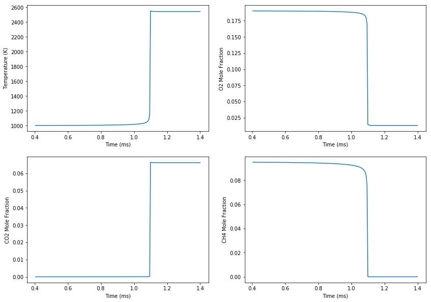

```python
rcParams['figure.figsize'] = (14, 10)

plt.clf()

plt.subplot(2, 2, 1)
plt.plot(times, data[:, 0])
plt.xlabel('Time (ms)')
plt.ylabel('Temperature (K)')

plt.subplot(2, 2, 2)
plt.plot(times, data[:, 1])
plt.xlabel('Time (ms)')
plt.ylabel('O2 Mole Fraction')

plt.subplot(2, 2, 3)
plt.plot(times, data[:, 2])
plt.xlabel('Time (ms)')
plt.ylabel('CO2 Mole Fraction')

plt.subplot(2, 2, 4)
plt.plot(times, data[:, 3])
plt.xlabel('Time (ms)')
plt.ylabel('CH4 Mole Fraction')

plt.show()
```

Try to modify the script by creating an **IdealGasConstPressureReactor** instead of setting the environment into a reservoir to maintain the pressure.

### Reset gas state and set the new IdealGasConstPressureReactor

```python
# Mechanisms used for the process
gri3 = ct.Solution('gri30.xml')

# Gas state
gri3.TPX = 1000.0, ct.one_atm, 'CH4:0.5,O2:1,N2:3.76'

r = ct.IdealGasConstPressureReactor(gri3)

# Prepare the simulation with a ReactorNet object
sim = ct.ReactorNet([r])
time = 4.e-1
```

### Simulate the new case

```python
# Arrays to hold the datas
times = np.zeros(200)
data = np.zeros((200, 4))

# Advance the simulation in time
print(('%10s %10s %10s %14s' % ('t [s]', 'T [K]', 'P [Pa]', 'h [J/kg]')))
for n in range(200):
    time += 5.e-3
    sim.advance(time)
    times[n] = time  # time in s
    data[n, 0] = r.T
    data[n, 1:] = r.thermo['O2', 'CO2', 'CH4'].X
    print(('%10.3e %10.3f %10.3f %14.6e' % (sim.time, r.T,
                                            r.thermo.P, r.thermo.h)))
```

```
     t [s]      T [K]     P [Pa]       h [J/kg]
 4.050e-01   1000.862 101325.000   5.879515e+05
 4.100e-01   1000.883 101325.000   5.879515e+05
 4.150e-01   1000.905 101325.000   5.879515e+05
 4.200e-01   1000.927 101325.000   5.879515e+05
 4.250e-01   1000.950 101325.000   5.879515e+05
 4.300e-01   1000.973 101325.000   5.879515e+05
 4.350e-01   1000.996 101325.000   5.879515e+05
 4.400e-01   1001.020 101325.000   5.879515e+05
 4.450e-01   1001.044 101325.000   5.879515e+05
 4.500e-01   1001.069 101325.000   5.879515e+05
 4.550e-01   1001.094 101325.000   5.879515e+05
 4.600e-01   1001.120 101325.000   5.879515e+05
 4.650e-01   1001.146 101325.000   5.879515e+05
 4.700e-01   1001.173 101325.000   5.879515e+05
 4.750e-01   1001.200 101325.000   5.879515e+05
 4.800e-01   1001.228 101325.000   5.879515e+05
 4.850e-01   1001.257 101325.000   5.879515e+05
 4.900e-01   1001.286 101325.000   5.879515e+05
 4.950e-01   1001.315 101325.000   5.879515e+05
 5.000e-01   1001.345 101325.000   5.879515e+05
 5.050e-01   1001.376 101325.000   5.879515e+05
 5.100e-01   1001.407 101325.000   5.879515e+05
 5.150e-01   1001.439 101325.000   5.879515e+05
 5.200e-01   1001.471 101325.000   5.879515e+05
 5.250e-01   1001.504 101325.000   5.879515e+05
 5.300e-01   1001.538 101325.000   5.879515e+05
 5.350e-01   1001.573 101325.000   5.879515e+05
 5.400e-01   1001.608 101325.000   5.879515e+05
 5.450e-01   1001.644 101325.000   5.879515e+05
 5.500e-01   1001.680 101325.000   5.879515e+05
 5.550e-01   1001.718 101325.000   5.879515e+05
 5.600e-01   1001.756 101325.000   5.879515e+05
 5.650e-01   1001.795 101325.000   5.879515e+05
 5.700e-01   1001.834 101325.000   5.879515e+05
 5.750e-01   1001.875 101325.000   5.879515e+05
 5.800e-01   1001.916 101325.000   5.879515e+05
 5.850e-01   1001.958 101325.000   5.879515e+05
 5.900e-01   1002.001 101325.000   5.879515e+05
 5.950e-01   1002.045 101325.000   5.879515e+05
```

[output cut: 146 more lines]

```
 1.330e+00   2541.146 101325.000   5.879515e+05
 1.335e+00   2541.146 101325.000   5.879515e+05
 1.340e+00   2541.146 101325.000   5.879515e+05
 1.345e+00   2541.146 101325.000   5.879515e+05
 1.350e+00   2541.146 101325.000   5.879515e+05
 1.355e+00   2541.146 101325.000   5.879515e+05
 1.360e+00   2541.146 101325.000   5.879515e+05
 1.365e+00   2541.146 101325.000   5.879515e+05
 1.370e+00   2541.146 101325.000   5.879515e+05
 1.375e+00   2541.146 101325.000   5.879515e+05
 1.380e+00   2541.146 101325.000   5.879515e+05
 1.385e+00   2541.146 101325.000   5.879515e+05
 1.390e+00   2541.146 101325.000   5.879515e+05
 1.395e+00   2541.146 101325.000   5.879515e+05
 1.400e+00   2541.146 101325.000   5.879515e+05
```

### Plot the results and compare with the previous one

```python
rcParams['figure.figsize'] = (14, 10)

plt.clf()

plt.subplot(2, 2, 1)
plt.plot(times, data[:, 0])
plt.xlabel('Time (ms)')
plt.ylabel('Temperature (K)')

plt.subplot(2, 2, 2)
plt.plot(times, data[:, 1])
plt.xlabel('Time (ms)')
plt.ylabel('O2 Mole Fraction')

plt.subplot(2, 2, 3)
plt.plot(times, data[:, 2])
plt.xlabel('Time (ms)')
plt.ylabel('CO2 Mole Fraction')

plt.subplot(2, 2, 4)
plt.plot(times, data[:, 3])
plt.xlabel('Time (ms)')
plt.ylabel('CH4 Mole Fraction')

plt.show()
```

[output not shown]

## 4. An example of application : mixing two streams

Up until now, we have seen how to generate simple closed vessels. However, it is sometimes interesting to mix different streams, or to feed the exhaust of a reservoir with constant parameters to a reacting reactor. In this exercise, we will design a script that simulates the stoichiometric constant volume mixing of a stream of air with a stream of pure gaseous methane.

[figure not shown]

### Set the two gases and the molar mass associated

You will have to :  
- set a first gas a with an air mixture at 0.21 of O2, 0.01 of AR and 0.78 of N2  
- set a second gas b with a gri30 mixture at 1 of CH4

```python
gas_a = ct.Solution('air.xml')
gas_a.TPX = 300, ct.one_atm, 'O2:0.21, N2:0.78, AR:0.01'
mw_a = gas_a.mean_molecular_weight/1000 #kg/mol

gas_b = ct.Solution('gri30.xml')
gas_b.TPX = 300.0, ct.one_atm, 'CH4:1'
mw_b = gas_b.mean_molecular_weight/1000 #kg/mol
```

### Creation of two reservoirs and an exhaust one (ReactorBase)

You will have to :  
- set a first reservoir from gas a  
- set a second reservoir from gas b  
- set a downstream reservoir filled with gas b

```python
res_a = ct.Reservoir(gas_a)
res_b = ct.Reservoir(gas_b)
downstream = ct.Reservoir(gas_b)
```

### Generate the reactor that will receive the mixed stream (ReactorBase)

You will have to :  
- change the condition of the gas b to respect an air mix.  
- create and IdealGasReactor with the energy equation set to 'on'.

```python
gas_b.TPX = 300, ct.one_atm, 'O2:1., N2:3.78, CH4:0.5'
mixer = ct.IdealGasReactor(gas_b, energy='on')
```

Watch out here, the mixture should be the one of gas_b, as the reactions will occur with the mechanism from gri30 (and not from the air).

### Creation of the mass flow controller that will control the mixing (FlowDevice)

Now that you have specified all the elements of the reactor, you need to detail the link between them. This is what is done in the following lines :

```python
mfca = ct.MassFlowController(res_a, mixer, mdot=mw_a*2./0.21)
mfcb = ct.MassFlowController(res_b, mixer, mdot=mw_b*1.0)
```

### Creation of the valve between the mixer and the downstream (FlowDevice)

Finally, the valve is created.

```python
outlet = ct.Valve(mixer, downstream, K=10.0)
```

This valve will enable the system to keep a constant pressure at the inlet of the mixer and at the outlet.

### Creation of the net reactor to compute simulation

**You need to create the ReactorNet with the mixer.**

```python
sim = ct.ReactorNet([mixer])
```

```python
# Since the mixer is a reactor, we need to integrate in time to reach steady
# state. A few residence times should be enough.
print('{0:>14s} {1:>14s} {2:>14s} {3:>14s} {4:>14s}'.format('t [s]', 'T [K]', 'h [J/kg]', 'P [Pa]', 'X_CH4'))
t = 0.0
for n in range(100):
    tres = mixer.mass/(mfca.mdot(t) + mfcb.mdot(t))
    t += 2*tres
    sim.advance(t)
    print('{0:14.5g} {1:14.5g} {2:14.5g} {3:14.5g} {4:14.5g}'.format(t, mixer.T, mixer.thermo.h, mixer.thermo.P, mixer.thermo['CH4'].X[0]))

print(mixer.thermo.report())
```

```
         t [s]          T [K]       h [J/kg]         P [Pa]          X_CH4
        7.6903            300    -2.5352e+05     1.0133e+05       0.094978
        15.406            300    -2.5351e+05     1.0133e+05       0.095017
        23.126            300    -2.5351e+05     1.0133e+05       0.095022
        30.846            300    -2.5351e+05     1.0133e+05       0.095023
        38.566            300    -2.5351e+05     1.0133e+05       0.095023
        46.286            300    -2.5351e+05     1.0133e+05       0.095023
        54.006            300    -2.5351e+05     1.0133e+05       0.095023
        61.726            300    -2.5351e+05     1.0133e+05       0.095023
        69.446            300    -2.5351e+05     1.0133e+05       0.095023
        77.166            300    -2.5351e+05     1.0133e+05       0.095023
        84.886            300    -2.5351e+05     1.0133e+05       0.095023
        92.606            300    -2.5351e+05     1.0133e+05       0.095023
        100.33            300    -2.5351e+05     1.0133e+05       0.095023
        108.05            300    -2.5351e+05     1.0133e+05       0.095023
        115.77            300    -2.5351e+05     1.0133e+05       0.095023
        123.49            300    -2.5351e+05     1.0133e+05       0.095023
        131.21            300    -2.5351e+05     1.0133e+05       0.095023
        138.93            300    -2.5351e+05     1.0133e+05       0.095023
        146.65            300    -2.5351e+05     1.0133e+05       0.095023
        154.37            300    -2.5351e+05     1.0133e+05       0.095023
        162.09            300    -2.5351e+05     1.0133e+05       0.095023
        169.81            300    -2.5351e+05     1.0133e+05       0.095023
        177.53            300    -2.5351e+05     1.0133e+05       0.095023
        185.25            300    -2.5351e+05     1.0133e+05       0.095023
        192.97            300    -2.5351e+05     1.0133e+05       0.095023
        200.69            300    -2.5351e+05     1.0133e+05       0.095023
        208.41            300    -2.5351e+05     1.0133e+05       0.095023
        216.13            300    -2.5351e+05     1.0133e+05       0.095023
        223.85            300    -2.5351e+05     1.0133e+05       0.095023
        231.57            300    -2.5351e+05     1.0133e+05       0.095023
        239.29            300    -2.5351e+05     1.0133e+05       0.095023
        247.01            300    -2.5351e+05     1.0133e+05       0.095023
        254.73            300    -2.5351e+05     1.0133e+05       0.095023
        262.45            300    -2.5351e+05     1.0133e+05       0.095023
        270.17            300    -2.5351e+05     1.0133e+05       0.095023
        277.89            300    -2.5351e+05     1.0133e+05       0.095023
        285.61            300    -2.5351e+05     1.0133e+05       0.095023
        293.33            300    -2.5351e+05     1.0133e+05       0.095023
        301.05            300    -2.5351e+05     1.0133e+05       0.095023
```

[output cut: 70 more lines]

```
                       -----------      ------------
          enthalpy     -2.5351e+05       -7.033e+06     J
   internal energy     -3.4342e+05       -9.527e+06     J
           entropy            7222        2.003e+05     J/K
    Gibbs function     -2.4201e+06       -6.714e+07     J
 heat capacity c_p          1070.4         2.97e+04     J/K
 heat capacity c_v          770.71        2.138e+04     J/K

                           X                 Y          Chem. Pot. / RT
                     -------------     ------------     ------------
                O2       0.190045         0.219211         -26.3342
               CH4      0.0950226        0.0549513         -54.6765
                N2       0.705882         0.712806         -23.3814
                AR     0.00904977        0.0130318         -23.3151
     [  +49 minor]    4.49034e-33      3.88811e-33
```

Notice that the gas did not ignite, and that the composition is indeed stoichiometric. We could trigger the ignition, by assuming that the reactor is 'already lit'. To do so, you need to initialize the content of the reactor with hot gases. The simplest way to do so is by filling it with stoichiometric mixture of air and methane at equilibrium. This is easily done by replacing the lines :

[output not shown]

with :

```
gas_b.TPX = 300.0,ct.one_atm,'O2:1., N2:3.78, CH4:0.5'
gas_b.equilibrate("HP")
mixer = ct.IdealGasReactor(gas_b)
```

## 5. Autoignition timing

### Create the gas object

```python
gas = ct.Solution('gri30.cti')
gas.TPX = 1250, ct.one_atm, 'CH4:0.5, O2:1, N2:3.76'
```

### Initialisation of the different values

```python
# Initial temperatures
Temperature_range = list(range(800, 1700, 100))

# Specify the number of time steps and the time step size
nt = 100000
dt = 1.e-4  # s

# Storing auto ignitions
auto_ignitions = []
```

```python
for index, Temperature in enumerate(Temperature_range):
    #################################################################
    # Initial temperature, Pressure and stoichiometry
    gas.TPX = Temperature, ct.one_atm, 'CH4:0.5, O2:1, N2:3.76'
    # Create the batch reactor
    r = ct.IdealGasReactor(gas)
    # Now create a reactor network consisting of the single batch reactor
    sim = ct.ReactorNet([r])
    # Storage space
    mfrac = []
    # ...
    time = []
    temperature = []
    HR = []
    # Run the simulation
    # Initial simulation time
    current_time = 0.0
    # Loop for nt time steps of dt seconds.
    for n in range(nt):
        current_time += dt
        sim.advance(current_time)
        time.append(current_time)
        temperature.append(r.T)
        mfrac.append(r.thermo.Y)
        HR.append(- np.dot(gas.net_production_rates, gas.partial_molar_enthalpies))
    #################################################################
    # Catch the autoignition timing
    #################################################################
    # Get the ignition delay time by the maximum value of the Heat Release rate
    auto_ignition = time[HR.index(max(HR))]
    print('For T = ' + str(Temperature) + ', Autoignition time = ' + str(auto_ignition) + ' s')
    # Posterity
    FinalTemp = temperature[nt - 1]
    auto_ignitions.append(auto_ignition)
    # #################################################################
    # # Save results
    # #################################################################
    # # write output CSV file for importing into Excel
    # csv_file = '3-Output/Phi-1_P-1_T-' + str(Temperature) + '_UV.csv'
    # with open(csv_file, 'w') as outfile:
    # writer = csv.writer(outfile)
    # writer.writerow(['Auto ignition time [s]', 'Final Temperature [K]'] + gas.species_names)
    # writer.writerow([auto_ignition, FinalTemp] + list(mfrac[:]))
    # print('output written to ' + csv_file)
T_invert = [1000 / Temperature for Temperature in Temperature_range]
```

```
For T = 800, Autoignition time = 9.999999999990033 s
For T = 900, Autoignition time = 7.055299999996896 s
For T = 1000, Autoignition time = 1.066899999999899 s
For T = 1100, Autoignition time = 0.19789999999999452 s
For T = 1200, Autoignition time = 0.043400000000000216 s
For T = 1300, Autoignition time = 0.011099999999999988 s
For T = 1400, Autoignition time = 0.0032999999999999982 s
For T = 1500, Autoignition time = 0.0011000000000000003 s
For T = 1600, Autoignition time = 0.0004 s
```

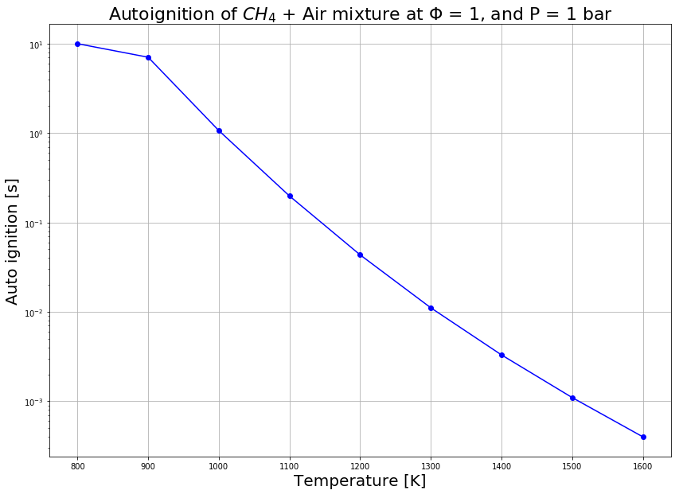

```python
#################################################################
# Plot results
#################################################################
# create plot
plt.plot(Temperature_range, auto_ignitions, 'b-o')
plt.xlabel(r'Temperature [K]', fontsize=20)
plt.ylabel("Auto ignition [s]", fontsize=20)
plt.yscale('log')
plt.title(r'Autoignition of $CH_{4}$ + Air mixture at $\Phi$ = 1, and P = 1 bar',
fontsize=22, horizontalalignment='center')
plt.axis(fontsize=20)
plt.grid()
plt.show()
```

This is a typical curve of the auto-ignition time as a function of the initial temperature, meaning that when the temperature increases, this time is reduced.